# Lecture 5: Loops

In the previous class we:

- Introduced boolean types and if/else statments
- Introduced a type of structure with indendented code

In this class we will:

- Talk about basic manipulation of lists
- Introduce "For" Loops and examples of key algorithms

## I. Import Libraries

```python
# the "numPy" library is used for mathematical operations
# the "matplotlib" library is for generating graphs
# the "pandas" library is for manipualting datasets
# 2/5/2025

import numpy as np
import matplotlib.pyplot as plt
import pandas as pd # library for data manipulation and analysis
```

## II. Manipulating Lists

Blank slate: Lists with null values

- We've seen "int", "float", "str", "boleean"
- There is also "None" (or null)
- Can add real values later

```python
# Simply type "None"

list_answers = [None,None,None] # none is a placeholder for something to be inserted later

print(list_answers)
```

```
[None, None, None]
```

Assigning/replacing values to lists

```python
# Assign values with the command "list_answers[index] = value".
# Let's assign names! Which ones do you like?

# What's the name of your hometown?
list_answers[0] = "Nashville"

# redefining more variables
list_answers[1] = "Orlando"

# can be useful for filling out information as we go, filling out lists
```

```python
list_answers
```

[output not shown]

Appending values to lists

```python
# We can start an empty list with []
# Use the command "new_list.append(item)" with the function "append()"
# an an arbitrary value of "item"

new_list = [] #appending is more appropriate when you don't know the fixed length list
new_list.append("Nashville")
new_list.append("Bogota")
# new_list.append()

print(new_list)

new_list.append("Theena")
print(new_list)
# python is an object oriented language, we have features and things associated with those objects
# we are gradually updating this object (list) until it has all the information we want
```

```
['Nashville', 'Bogota']
['Nashville', 'Bogota', 'Theena']
```

Lists with repeated values

```python
list_answers
```

[output not shown]

```python
# Repeat a single value 30 times
list_two_rep = [7] * 30

# Repeat a list 4 times
list_answers_rep = list_answers * 4

# Repeat of 8 null values
list_none_rep = [None] * 8

print(list_two_rep)
print(list_answers_rep)
print(list_none_rep)

# testing this again
Bogota = list_answers[1] * 4
print(Bogota) # no spaces

Bogota1 = [list_answers[1]] * 4
print(Bogota1) # proper space formatting
```

```
[7, 7, 7, 7, 7, 7, 7, 7, 7, 7, 7, 7, 7, 7, 7, 7, 7, 7, 7, 7, 7, 7, 7, 7, 7, 7, 7, 7, 7, 7]
['Nashville', 'Orlando', None, 'Nashville', 'Orlando', None, 'Nashville', 'Orlando', None, 'Nashville', 'Orlando', None]
[None, None, None, None, None, None, None, None]
OrlandoOrlandoOrlandoOrlando
['Orlando', 'Orlando', 'Orlando', 'Orlando']
```

Common Pitfall: Multiplying lists vs arrays

```python
# When you multipy a list times a number you repeat the list
list_a = [1,2,3]
print( list_a*4)

# When you multipy an array times a number, you multiply each element
vec_a = np.array(list_a)
print( vec_a * 4)
```

```
[1, 2, 3, 1, 2, 3, 1, 2, 3, 1, 2, 3]
[ 4  8 12]
```

Counting length of vectors

```python
# len() is a function that counts the number of elements

print(len(list_answers))
print(len(list_two_rep))
print(len(list_answers_rep))
```

```
3
30
12
```

Try it yourself!

- Create an empty list called "list_personal"
- Add two more values using ".append"
- Find the total length of the list
- Change the last value to "Last element"

```python
list_personal = []
list_personal.append("eclair")
list_personal.append("mousse") # .append.append doesn't work
print(len(list_personal))
print(list_personal)

list_personal[1] = "creme brulee"
print(list_personal)

list_personal[-1] = "crepe"
print(list_personal)

list_personal[len(list_personal)-1] = "croissant"
print(list_personal)
```

```
2
['eclair', 'mousse']
['eclair', 'creme brulee']
['eclair', 'crepe']
['eclair', 'croissant']
```

## III. For Loops

One of the most important elements of computation is repetition

- We can do this with "loops".
- In the next examples, we repeat a task for each element in a list

Consider an example with three elements

[figure not shown]

Use concise syntax with a for-loop

```
for value in list_values:
        Body
```

Customized Messages

```python
#------------------------------------------------------------------------------#
#-------------   This produces exactly the same output as running -------------#
#
#    id_list = ["KIA", "Ferrari", "Ford", "Tesla"]
#    print("Dear customer, we are writing about your " + id_list[0] + "" car.")
#    print("Dear customer, we are writing about your " + id_list[1] + "" car.")
#    print("Dear customer, we are writing about your " + id_list[2] + "" car.")
#    print("Dear customer, we are writing about your " + id_list[3] + "" car.")
#
# Here we're concatenating strings with a "+" sign
#
#------------------------------------------------------------------------------#


list_ids = ["KIA", "Ferrari", "Ford", "Tesla"]

for id in list_ids: # automatically goes in sequence for every item in the ID list
    print(id)
    print("Dear customer, we are writing about your "  + id + " car.")

list_lulu_names = ["Makenna", "Serena", "Brianna", "Sofia", "Emma", "Angelina"]

for name in list_lulu_names:
    print(name)
    print("I almost named my sister " + name)
```

```
KIA
Dear customer, we are writing about your KIA car.
Ferrari
Dear customer, we are writing about your Ferrari car.
Ford
Dear customer, we are writing about your Ford car.
Tesla
Dear customer, we are writing about your Tesla car.
Makenna
I almost named my sister Makenna
Serena
I almost named my sister Serena
Brianna
I almost named my sister Brianna
Sofia
I almost named my sister Sofia
Emma
I almost named my sister Emma
Angelina
I almost named my sister Angelina
```

```python
for id in list_ids + ['a', 'b', 'c']:
    print(id)
```

```
KIA
Ferrari
Ford
Tesla
a
b
c
```

Customized Messages + Numbering

- Initiate "index = 1" before the loop
- Add "index = index + 1" at the end of the body

```python
#------------------------------------------------------------------------------#
# One way to construct a sequence manually, is to gradually add numbers, e.g.
#
#     index = 1
#     index = index + 1
#     index = index + 1
#     index = index + 1
#     etc
#
#     We will do this automatically for a for loop!
#
#     Note: We can use "str(index)" to convert this to a string
#
#------------------------------------------------------------------------------#


list_ids = ["KIA", "Ferrari", "Ford", "Tesla"]

index = 1
print('We are out of the loop', index)
for id in list_ids:
    print("Dear customer, your position is " + str(index) + " on the waitlist" +
           " and your car brand is " + id )
    index = index + 1
    print('We are inside the loop', index)
```

```
We are out of the loop 1
Dear customer, your position is 1 on the waitlist and your car brand is KIA
We are inside the loop 2
Dear customer, your position is 2 on the waitlist and your car brand is Ferrari
We are inside the loop 3
Dear customer, your position is 3 on the waitlist and your car brand is Ford
We are inside the loop 4
Dear customer, your position is 4 on the waitlist and your car brand is Tesla
We are inside the loop 5
```

```python
for i in range(len(list_ids)):
    print("Dear customer, your position is " + str(i+1) + " on the waitlist" +
           " and your car brand is " + list_ids[i])


# which one to use dependson fixed vs variabl list, both can be combined.
```

```
Dear customer, your position is 1 on the waitlist and your car brand is KIA
Dear customer, your position is 2 on the waitlist and your car brand is Ferrari
Dear customer, your position is 3 on the waitlist and your car brand is Ford
Dear customer, your position is 4 on the waitlist and your car brand is Tesla
```

Plots for multiple variables

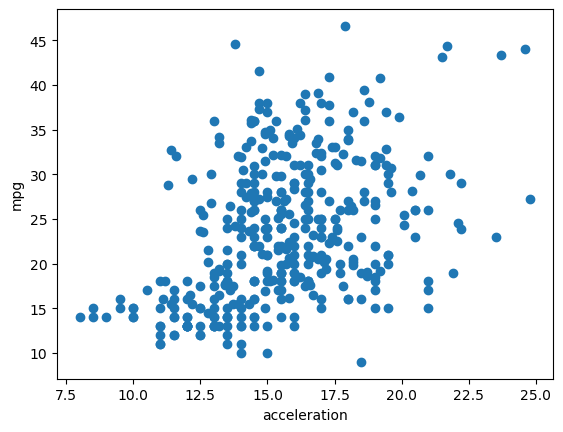

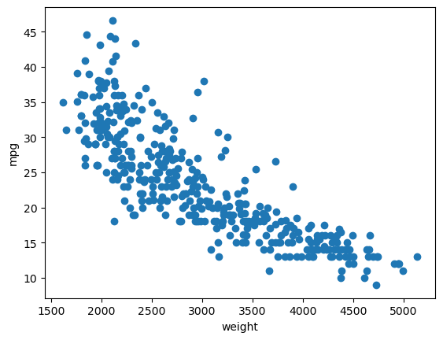

```python
#------------------------------------------------------------------------------#
#-------------   This produces exactly the same output as running -------------#
#
#    carfeatures = pd.read_csv("data/features.csv")
#    list_vars = ["acceleration","weight"]
#
#    variable_name = "acceleration"
#    plt.scatter(x= carfeatures[variable_name], y = carfeatures["mpg"])
#    plt.ylabel("mpg")
#    plt.xlabel(variable_name)
#    plt.show()
#
#    variable_name = "weight"
#    plt.scatter(x= carfeatures[variable_name], y = carfeatures["mpg"])
#    plt.ylabel("mpg")
#    plt.xlabel(variable_name)
#    plt.show()
#
#------------------------------------------------------------------------------#

carfeatures = pd.read_csv("data/features.csv")
list_vars   = ["acceleration","weight"]

for variable_name in list_vars:
    plt.scatter(x= carfeatures[variable_name], y = carfeatures["mpg"])
    plt.ylabel("mpg")
    plt.xlabel(variable_name)
    plt.show()

# Try adding more variables to the analysis!!!
# want to edit which graph we produce
```

Plots for multiple variables + Numbering

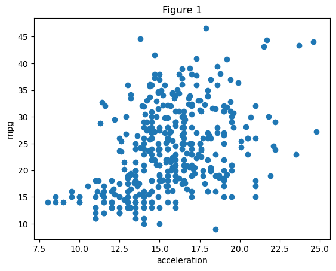

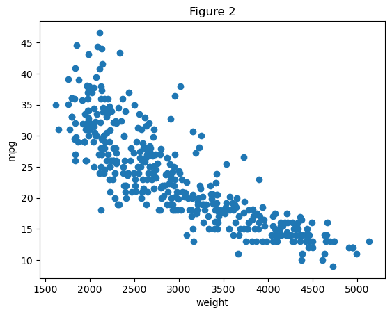

```python
carfeatures = pd.read_csv("data/features.csv")
list_vars   = ["acceleration","weight"]

index = 1
for variable_name in list_vars:
    plt.scatter(x= carfeatures[variable_name], y = carfeatures["mpg"])
    plt.ylabel("mpg")
    plt.xlabel(variable_name)
    plt.title("Figure " + str(index))
    plt.show()
    index = index + 1
```

Math Operations + Numbering (Filling)

$ y = x^2 + 2x$

```
[3, 8, 24, 35, 48, 63, 80, 99, 120]
```

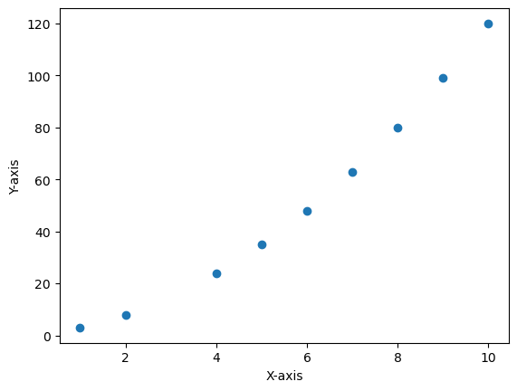

```python
# Create a list of x-values list_x = [1,2,4,5, ..., 50]
# Create a list of y-values to fill in later.
# The "range(

list_x = [1,2,4,5,6,7,8,9,10]
list_y = [None] * len(list_x)

# Create an index
index = 0
for x in list_x:
    list_y[index] = list_x[index]**2 + 2*list_x[index]
    index = index + 1

# Display results visually
print(list_y)
plt.scatter(list_x, list_y)
plt.xlabel("X-axis")
plt.ylabel("Y-axis")
```

# Additional Exercises

Try it yourself!

- Create a histogram and number the figures for each of the variables:

list_variables = ["weight", "acceleration","mpg"]

```python
# Write down your own code:
```

Try it yourself!

- Create a new object called

list_datasets = ["features.csv","worlbank_wdi_2019.csv"]

- Run a for loop over this list:
- Read each of the datasets using "pd.read_csv()"
- Print a table of descriptive statistics for each dataset

```python
# Write down your own code:
```

# IV. Resources

Check out additional examples at:

- https://allendowney.github.io/ElementsOfDataScience/04_loops.html

Pro tips:

- Write the list and heading of the for loop first
- If using numbering, start by a simple example that prints the index
- After this, start writing the body of the loop
- Always check output
- Good way to check output: Tables and graphs!

# V. Other variations of Loops

Math Operations (Appending)

$ y = x^2 + 2x$

```
[3, 8, 24, 35, 48, 63, 80, 99, 120]
```

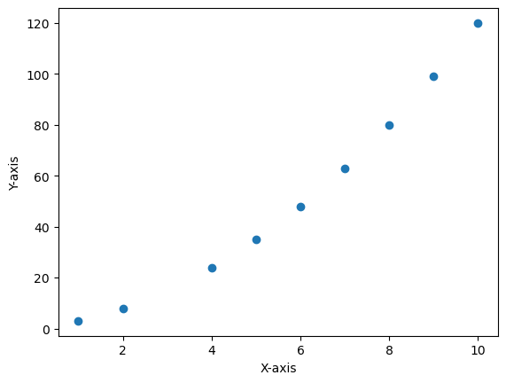

```python
# Create a list of x-values list_x = [1,2,4,5, ..., 50]
# Start an empty list of y-values with []

list_x = [1,2,4,5,6,7,8,9,10]
list_y = []

# Create an index
for x in list_x:
    y = x**2 + 2*x
    list_y.append(y)

# Display results visually
print(list_y)
plt.scatter(list_x, list_y)
plt.xlabel("X-axis")
plt.ylabel("Y-axis")
```